# UFO Analysis by Judah Perillo

## original: winter semester 2017

### SI370 Data Exploration

### Professor: Eytan Adar

## updates: June 2022

### UFO data from NUFORC, .csv file from my own data scrape: https://media.githubusercontent.com/media/judahorli/big-ufo-data/main/nuforcData_2022.csv

### Key Questions:

1. Are there trends of UFO reports over time? Do seasonal trends exist?
2. Are UFO summaries mostly positive, negative, or neutral in language? Or, are reports tinged with fear, curiosity, excitement?
3. Are certain UFO shapes more prevalent in reports than others?
4. Are certain locations more akin to UFO reports?

```python
import numpy as np
from matplotlib import pyplot as plt
from IPython.display import HTML, display
from PIL import Image
from datetime import datetime
from dateutil.parser import parse
import scipy as sp
import scipy.spatial.distance as spd
import scipy.cluster.hierarchy as sph
import sklearn as sk
import sklearn.ensemble as skens
import sklearn.naive_bayes as sknb
import sklearn.tree as sktree
import sklearn.metrics as skm
import sklearn.cluster as skc
import sklearn.decomposition as skd
import sklearn.mixture as skmix
import sklearn.manifold as manifold
import sklearn.model_selection as skcv
import sklearn.decomposition as skd
import sklearn.feature_extraction.text as skft
import sklearn.pipeline as skpipe
import pandas as pd
import matplotlib.pyplot as plt
%matplotlib inline
import seaborn as sns
sns.set(style='white', color_codes=True, font_scale=1.3)
from sklearn.cluster import KMeans
from sklearn.metrics import silhouette_samples, silhouette_score
import matplotlib.cm as cm
import re
import os.path
import nltk
import math
from nltk.corpus import stopwords
import collections
import os

%matplotlib inline
```

```python
# Filter all warnings.
import warnings
warnings.filterwarnings('ignore')
```

```python
ufo_og = pd.read_csv('https://media.githubusercontent.com/media/judahorli/big-ufo-data/main/nuforcData_2022.csv')
ufo_og = ufo_og.drop("Unnamed: 0", axis=1)
```

```python
ufo_og.Occurred = pd.to_datetime(ufo_og.Occurred, errors = 'coerce')
ufo_og = ufo_og.set_index(ufo_og.Occurred)
```

```python
ufo_us = ufo_og[ufo_og.Country == 'USA'] # create dataframe for only us reports
ufo_us.size
```

```
1473048
```

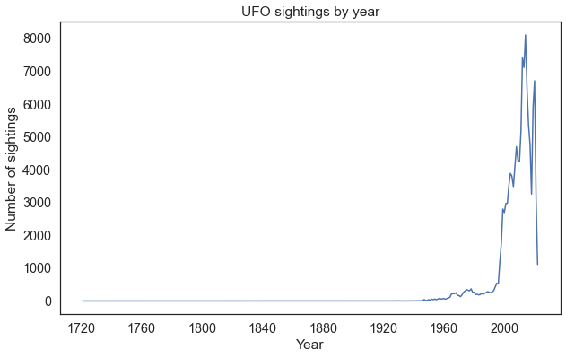

```python
ufo_year = ufo_og.resample('AS').count()
plt.figure(figsize=(10,6))
plt.title('UFO sightings by year')
plt.xlabel('Year')
plt.ylabel('Number of sightings')
plt.plot(ufo_year['State'])
```

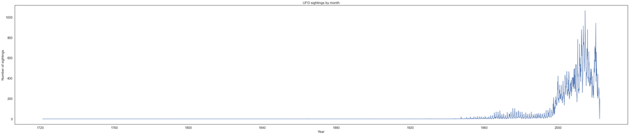

```python
ufo_month = ufo_og.resample('M').count()
plt.figure(figsize=(50,10))
plt.title('UFO sightings by month')
plt.xlabel('Year')
plt.ylabel('Number of sightings')
plt.plot(ufo_month['State'])
```

### Obviously more recent data is more interesting, up until around 1950 UFO reports are pretty rare

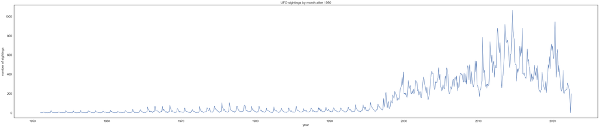

```python
ufo_post1950 = ufo_month.copy()
ufo_post1950 = ufo_post1950[ufo_post1950.index.year > 1950]
plt.figure(figsize=(50,10))
plt.title('UFO sightings by month after 1950')
plt.xlabel('year')
plt.ylabel('number of sightings')
plt.plot(ufo_post1950['State'])
```

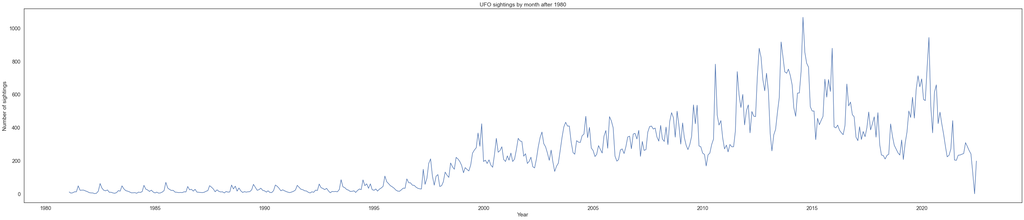

```python
ufo_post1980 = ufo_month.copy()
ufo_post1980 = ufo_post1980[ufo_post1980.index.year > 1980]
plt.figure(figsize=(50,10))
plt.title('UFO sightings by month after 1980')
plt.xlabel('Year')
plt.ylabel('Number of sightings')
plt.plot(ufo_post1980['State'])
```

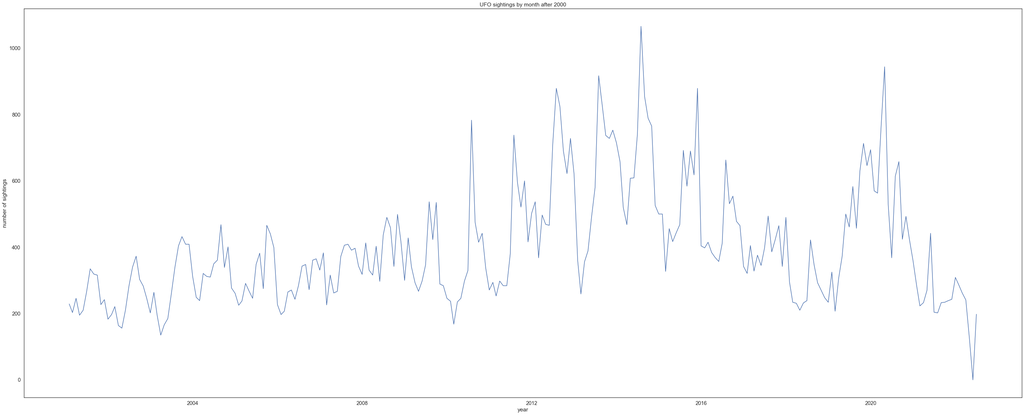

```python
ufo_post2000 = ufo_month.copy()
ufo_post2000 = ufo_post2000[ufo_post2000.index.year > 2000]
plt.figure(figsize=(50,20))
plt.title('UFO sightings by month after 2000')
plt.xlabel('year')
plt.ylabel('number of sightings')
plt.plot(ufo_post2000['State'])
```

### Reports after 2000 appear to have some seasonality.

```python
states = {
    'AK': 'ALASKA',
    'AL': 'ALABAMA',
    'AR': 'ARKANSAS',
    'AZ': 'ARIZONA',
    'CA': 'CALIFORNIA',
    'CO': 'COLORADO',
    'CT': 'CONNECTICUT',
    'DC': 'DISTRICT OF COLUMBIA',
    'DE': 'DELAWARE',
    'FL': 'FLORIDA',
    'GA': 'GEORGIA',
    'HI': 'HAWAII',
    'IA': 'IOWA',
    'ID': 'IDAHO',
    'IL': 'ILLINOIS',
    'IN': 'INDIANA',
    'KS': 'KANSAS',
    'KY': 'KENTUCKY',
    'LA': 'LOUISIANA',
    'MA': 'MASSACHUSETTS',
    'MD': 'MARYLAND',
    'ME': 'MAINE',
    'MI': 'MICHIGAN',
    'MN': 'MINNESOTA',
    'MO': 'MISSOURI',
    'MS': 'MISSISSIPPI',
    'MT': 'MONTANA',
    'NC': 'NORTH CAROLINA',
    'ND': 'NORTH DAKOTA',
    'NE': 'NEBRASKA',
    'NH': 'NEW HAMPSHIRE',
    'NJ': 'NEW JERSEY',
    'NM': 'NEW MEXICO',
    'NV': 'NEVADA',
    'NY': 'NEW YORK',
    'OH': 'OHIO',
    'OK': 'OKLAHOMA',
    'OR': 'OREGON',
    'PA': 'PENNSYLVANIA',
    'RI': 'RHODE ISLAND',
    'SC': 'SOUTH CAROLINA',
    'SD': 'SOUTH DAKOTA',
    'TN': 'TENNESSEE',
    'TX': 'TEXAS',
    'UT': 'UTAH',
    'VA': 'VIRGINIA',
    'VT': 'VERMONT',
    'WA': 'WASHINGTON',
    'WI': 'WISCONSIN',
    'WV': 'WEST VIRGINIA',
    'WY': 'WYOMING'
}

# thanks to https://gist.github.com/JeffPaine/3083347
state_codes = list(states.keys())
```

```python
ufo_states = ufo_us[ufo_us.State.isin(state_codes)]
ufo_states["Shape"] = ufo_states["Shape"].str.lower()
```

```python
ufo_group = ufo_states.groupby(["State", "Shape"]).count()
ufo_group = ufo_group.unstack('State')['City']
ufo_group = ufo_group.fillna(0)
ufo_group
```

| State Shape | AK | AL | AR | AZ | CA | CO | CT | DC | DE | FL | ... | SD | TN | TX | UT | VA | VT | WA | WI | WV | WY |
| --- | --- | --- | --- | --- | --- | --- | --- | --- | --- | --- | --- | --- | --- | --- | --- | --- | --- | --- | --- | --- | --- |
| changed | 0.0 | 0.0 | 0.0 | 0.0 | 0.0 | 1.0 | 0.0 | 0.0 | 0.0 | 0.0 | ... | 0.0 | 0.0 | 0.0 | 0.0 | 0.0 | 0.0 | 0.0 | 0.0 | 0.0 | 0.0 |
| changing | 14.0 | 27.0 | 23.0 | 144.0 | 470.0 | 80.0 | 35.0 | 2.0 | 7.0 | 209.0 | ... | 7.0 | 45.0 | 151.0 | 49.0 | 61.0 | 12.0 | 148.0 | 47.0 | 15.0 | 8.0 |
| chevron | 2.0 | 16.0 | 19.0 | 47.0 | 227.0 | 69.0 | 19.0 | 0.0 | 4.0 | 109.0 | ... | 5.0 | 23.0 | 77.0 | 20.0 | 34.0 | 3.0 | 78.0 | 19.0 | 10.0 | 6.0 |
| cigar | 13.0 | 34.0 | 32.0 | 95.0 | 332.0 | 65.0 | 55.0 | 0.0 | 2.0 | 166.0 | ... | 7.0 | 77.0 | 165.0 | 30.0 | 68.0 | 14.0 | 104.0 | 60.0 | 18.0 | 5.0 |
| circle | 74.0 | 138.0 | 120.0 | 462.0 | 1561.0 | 285.0 | 223.0 | 3.0 | 57.0 | 862.0 | ... | 31.0 | 227.0 | 525.0 | 151.0 | 281.0 | 60.0 | 620.0 | 245.0 | 99.0 | 35.0 |
| cone | 2.0 | 3.0 | 4.0 | 25.0 | 58.0 | 8.0 | 7.0 | 0.0 | 1.0 | 21.0 | ... | 0.0 | 7.0 | 19.0 | 9.0 | 9.0 | 4.0 | 24.0 | 9.0 | 2.0 | 1.0 |
| crescent | 0.0 | 0.0 | 0.0 | 0.0 | 0.0 | 0.0 | 0.0 | 0.0 | 0.0 | 0.0 | ... | 0.0 | 0.0 | 0.0 | 0.0 | 0.0 | 0.0 | 0.0 | 1.0 | 0.0 | 0.0 |
| cross | 1.0 | 4.0 | 3.0 | 14.0 | 53.0 | 10.0 | 9.0 | 0.0 | 0.0 | 24.0 | ... | 0.0 | 5.0 | 13.0 | 3.0 | 6.0 | 5.0 | 17.0 | 7.0 | 4.0 | 0.0 |
| cylinder | 10.0 | 27.0 | 27.0 | 65.0 | 216.0 | 49.0 | 29.0 | 1.0 | 4.0 | 128.0 | ... | 8.0 | 59.0 | 95.0 | 18.0 | 41.0 | 12.0 | 103.0 | 31.0 | 26.0 | 7.0 |
| delta | 0.0 | 0.0 | 0.0 | 1.0 | 0.0 | 0.0 | 0.0 | 0.0 | 0.0 | 1.0 | ... | 0.0 | 1.0 | 1.0 | 0.0 | 1.0 | 0.0 | 3.0 | 0.0 | 0.0 | 0.0 |
| diamond | 9.0 | 20.0 | 15.0 | 56.0 | 246.0 | 33.0 | 30.0 | 0.0 | 6.0 | 104.0 | ... | 4.0 | 32.0 | 90.0 | 15.0 | 34.0 | 5.0 | 88.0 | 43.0 | 9.0 | 4.0 |
| disk | 43.0 | 71.0 | 64.0 | 231.0 | 942.0 | 154.0 | 96.0 | 1.0 | 23.0 | 403.0 | ... | 18.0 | 125.0 | 349.0 | 91.0 | 156.0 | 27.0 | 310.0 | 111.0 | 48.0 | 16.0 |
| dome | 0.0 | 0.0 | 0.0 | 0.0 | 0.0 | 0.0 | 0.0 | 0.0 | 0.0 | 0.0 | ... | 0.0 | 0.0 | 0.0 | 0.0 | 0.0 | 0.0 | 0.0 | 0.0 | 0.0 | 0.0 |
| egg | 2.0 | 16.0 | 7.0 | 47.0 | 147.0 | 23.0 | 17.0 | 0.0 | 4.0 | 61.0 | ... | 3.0 | 17.0 | 44.0 | 12.0 | 24.0 | 5.0 | 50.0 | 16.0 | 10.0 | 6.0 |
| fireball | 34.0 | 82.0 | 50.0 | 305.0 | 1116.0 | 152.0 | 158.0 | 1.0 | 28.0 | 751.0 | ... | 23.0 | 134.0 | 302.0 | 86.0 | 172.0 | 38.0 | 512.0 | 184.0 | 47.0 | 25.0 |
| flare | 0.0 | 0.0 | 0.0 | 0.0 | 1.0 | 0.0 | 0.0 | 0.0 | 0.0 | 0.0 | ... | 0.0 | 0.0 | 0.0 | 0.0 | 0.0 | 0.0 | 0.0 | 0.0 | 0.0 | 0.0 |
| flash | 21.0 | 20.0 | 27.0 | 84.0 | 254.0 | 64.0 | 28.0 | 0.0 | 6.0 | 118.0 | ... | 7.0 | 33.0 | 89.0 | 28.0 | 48.0 | 11.0 | 130.0 | 39.0 | 8.0 | 5.0 |
| formation | 14.0 | 35.0 | 30.0 | 222.0 | 550.0 | 133.0 | 37.0 | 0.0 | 14.0 | 223.0 | ... | 16.0 | 61.0 | 186.0 | 67.0 | 74.0 | 23.0 | 212.0 | 104.0 | 24.0 | 17.0 |
| hexagon | 0.0 | 0.0 | 0.0 | 0.0 | 0.0 | 0.0 | 0.0 | 0.0 | 0.0 | 0.0 | ... | 0.0 | 0.0 | 0.0 | 0.0 | 0.0 | 0.0 | 0.0 | 0.0 | 0.0 | 0.0 |
| light | 145.0 | 264.0 | 245.0 | 1038.0 | 3092.0 | 583.0 | 336.0 | 5.0 | 59.0 | 1433.0 | ... | 81.0 | 373.0 | 1145.0 | 298.0 | 469.0 | 126.0 | 1424.0 | 523.0 | 184.0 | 86.0 |
| other | 33.0 | 82.0 | 70.0 | 366.0 | 1074.0 | 239.0 | 115.0 | 2.0 | 23.0 | 488.0 | ... | 26.0 | 135.0 | 442.0 | 86.0 | 159.0 | 37.0 | 458.0 | 144.0 | 51.0 | 29.0 |
| oval | 33.0 | 53.0 | 33.0 | 182.0 | 642.0 | 112.0 | 84.0 | 0.0 | 15.0 | 354.0 | ... | 15.0 | 103.0 | 297.0 | 52.0 | 104.0 | 21.0 | 279.0 | 78.0 | 42.0 | 15.0 |
| pyramid | 0.0 | 0.0 | 0.0 | 0.0 | 0.0 | 0.0 | 0.0 | 0.0 | 0.0 | 0.0 | ... | 0.0 | 0.0 | 0.0 | 0.0 | 0.0 | 0.0 | 0.0 | 0.0 | 0.0 | 0.0 |
| rectangle | 12.0 | 24.0 | 13.0 | 85.0 | 248.0 | 59.0 | 42.0 | 0.0 | 8.0 | 129.0 | ... | 4.0 | 33.0 | 109.0 | 18.0 | 44.0 | 14.0 | 101.0 | 28.0 | 10.0 | 3.0 |
| round | 0.0 | 0.0 | 0.0 | 0.0 | 1.0 | 0.0 | 0.0 | 0.0 | 0.0 | 0.0 | ... | 0.0 | 0.0 | 0.0 | 0.0 | 0.0 | 0.0 | 0.0 | 0.0 | 0.0 | 0.0 |
| sphere | 41.0 | 83.0 | 54.0 | 275.0 | 1053.0 | 216.0 | 98.0 | 1.0 | 32.0 | 517.0 | ... | 13.0 | 133.0 | 342.0 | 88.0 | 164.0 | 46.0 | 422.0 | 141.0 | 42.0 | 37.0 |
| star | 0.0 | 0.0 | 0.0 | 1.0 | 1.0 | 0.0 | 0.0 | 0.0 | 0.0 | 1.0 | ... | 0.0 | 0.0 | 3.0 | 0.0 | 0.0 | 0.0 | 1.0 | 0.0 | 0.0 | 0.0 |
| teardrop | 1.0 | 8.0 | 9.0 | 42.0 | 129.0 | 25.0 | 25.0 | 0.0 | 4.0 | 62.0 | ... | 4.0 | 15.0 | 61.0 | 15.0 | 17.0 | 2.0 | 41.0 | 24.0 | 6.0 | 4.0 |
| triangle | 43.0 | 131.0 | 136.0 | 359.0 | 1249.0 | 302.0 | 156.0 | 2.0 | 52.0 | 619.0 | ... | 35.0 | 230.0 | 566.0 | 128.0 | 226.0 | 46.0 | 514.0 | 208.0 | 89.0 | 31.0 |
| unknown | 39.0 | 83.0 | 87.0 | 295.0 | 938.0 | 188.0 | 131.0 | 1.0 | 25.0 | 512.0 | ... | 37.0 | 159.0 | 427.0 | 93.0 | 183.0 | 38.0 | 513.0 | 164.0 | 71.0 | 23.0 |

30 rows × 51 columns

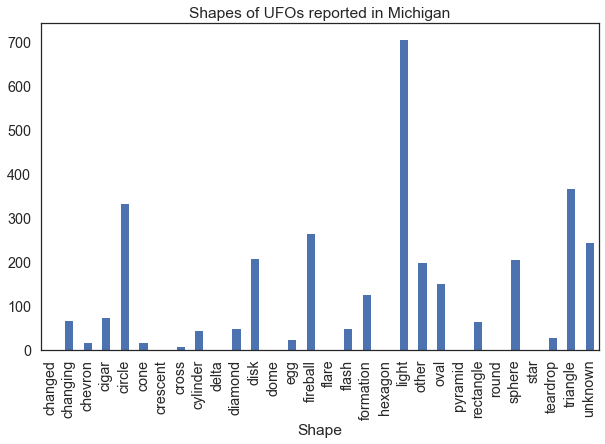

```python
ufo_group.MI.plot(kind='bar',title='Shapes of UFOs reported in Michigan',figsize=(10,6))
```

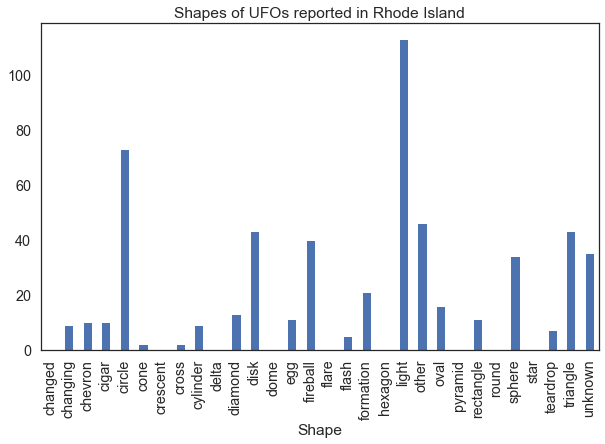

```python
ufo_group.RI.plot(kind='bar',title='Shapes of UFOs reported in Rhode Island',figsize=(10,6))
```

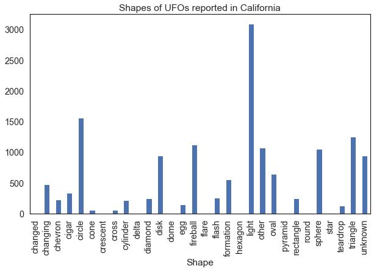

```python
ufo_group.CA.plot(kind='bar',title='Shapes of UFOs reported in California',figsize=(10,6))
```

```python
ufo_date = ufo_states.copy()
ufo_date = ufo_date.to_period('D')
### RESAMPLE date to just do year/month/day and not time.
ufo_date.index.names = ['Date']
ufo_date
```

| Date | Link | Occurred | Reported | Posted | City | State | Country | Shape | Duration | Characteristics | Summary | Images |
| --- | --- | --- | --- | --- | --- | --- | --- | --- | --- | --- | --- | --- |
| 2022-03-24 | http://www.nuforc.org/webreports/reports/167/S... | 2022-03-24 02:44:00 | 3/24/2022 03:09 | 4/22/2022 | Jemison | AL | USA | NaN | 2 secounds | NaN | Very very bright object fell from the sky at 2... | [] |
| 2022-03-23 | http://www.nuforc.org/webreports/reports/167/S... | 2022-03-23 14:55:00 | 4/20/2022 09:07 | 4/22/2022 | Mobile | AL | USA | NaN | NaN | NaN | MADAR Node 63 | [] |
| 2022-03-23 | http://www.nuforc.org/webreports/reports/167/S... | 2022-03-23 05:32:00 | 3/24/2022 20:41 | 4/22/2022 | Loxley | AL | USA | circle | 31seconds | There were lights on the object, There was an ... | This sighting is real.\n\nCraft was seen above... | [] |
| 2022-03-22 | http://www.nuforc.org/webreports/reports/167/S... | 2022-03-22 10:46:00 | 4/20/2022 09:17 | 4/22/2022 | Dothan | AL | USA | NaN | NaN | NaN | MADAR Node 195 | [] |
| 2022-03-19 | http://www.nuforc.org/webreports/reports/167/S... | 2022-03-19 20:30:00 | 3/20/2022 09:42 | 4/22/2022 | Rogersville | AL | USA | oval | Approximately 5-10 second | There were lights on the object, The object le... | First Ever Sighting: Green Aura came out of no... | [] |
| ... | ... | ... | ... | ... | ... | ... | ... | ... | ... | ... | ... | ... |
| 1951-07-03 | http://www.nuforc.org/webreports/reports/025/S... | 1951-07-03 12:00:00 | 10/15/2002 00:13 | 10/15/2002 | Green River | WY | USA | sphere | 5 to 7 min | NaN | Glowing white spherical large craft (50 to 100... | [] |
| 1949-06-30 | http://www.nuforc.org/webreports/reports/150/S... | 1949-06-30 23:00:00 | 11/17/2019 14:14 | 12/1/2019 | Little America (near) | WY | USA | disk | 5 minutes | There was an aura or haze around the object | One night as a child, I saw a little man in a ... | [] |
| 1871-06-30 | http://www.nuforc.org/webreports/reports/072/S... | 1871-06-30 14:00:00 | 9/28/2009 10:44 | 12/12/2009 | Yellowstone National Park | WY | USA | egg | not known | NaN | Old photos from 1871 show what appears to be o... | [] |
| 2022-06-21 | http://www.nuforc.org/webreports/reports/137/S... | 2022-06-21 20:04:00 | 12/14/2017 22:08 | 12/21/2017 | Wright | WY | USA | changing | 2+ hours | There was an aura or haze around the object, T... | Was standing outside. A huge bright green lig... | [] |
| 2022-06-21 | http://www.nuforc.org/webreports/reports/161/S... | 2022-06-21 12:00:00 | 1/7/2021 01:19 | 1/19/2021 | teton village wyoming | WY | USA | circle | daily | NaN | real machine found\n\nthe contact is ((woman's... | [] |

122155 rows × 12 columns

```python
counted = ufo_date.groupby(['State','City','Date']).count()
top = counted[counted.Country > 5]
top.sort_values('Country',ascending=False)
```

| State | City | Date | Link | Occurred | Reported | Posted | Country | Shape | Duration | Characteristics | Summary | Images |
| --- | --- | --- | --- | --- | --- | --- | --- | --- | --- | --- | --- | --- |
| IL | Tinley Park | 2004-10-31 | 56 | 56 | 56 | 56 | 56 | 56 | 55 | 48 | 56 | 56 |
|  |  | 2004-08-21 | 30 | 30 | 30 | 30 | 30 | 30 | 28 | 21 | 30 | 30 |
| AZ | Phoenix | 1997-03-13 | 25 | 25 | 25 | 25 | 25 | 21 | 22 | 18 | 25 | 25 |
| IL | Rockford | 2001-01-11 | 23 | 23 | 23 | 23 | 23 | 23 | 21 | 17 | 23 | 23 |
| NJ | Carteret | 2001-07-15 | 13 | 13 | 13 | 13 | 13 | 12 | 11 | 9 | 13 | 13 |
| IL | Tinley Park | 2005-09-30 | 12 | 12 | 12 | 12 | 12 | 12 | 12 | 7 | 12 | 12 |
|  | Orland Park | 2005-09-30 | 9 | 9 | 9 | 9 | 9 | 9 | 9 | 8 | 9 | 9 |
|  | Tinley Park | 2005-10-01 | 9 | 9 | 9 | 9 | 9 | 9 | 8 | 8 | 9 | 9 |
|  | Rockford | 2000-02-16 | 9 | 9 | 9 | 9 | 9 | 9 | 9 | 9 | 9 | 9 |
| OR | Portland | 2006-04-29 | 8 | 8 | 8 | 8 | 8 | 8 | 8 | 7 | 8 | 8 |
| OH | Columbus | 2013-07-06 | 8 | 8 | 8 | 8 | 8 | 8 | 8 | 8 | 8 | 8 |
| WA | Seattle | 2014-07-04 | 8 | 8 | 8 | 8 | 8 | 8 | 8 | 6 | 8 | 8 |
| AZ | Phoenix | 2008-04-21 | 8 | 8 | 8 | 8 | 8 | 8 | 8 | 7 | 8 | 8 |
| FL | Navarre | 2005-11-07 | 8 | 8 | 8 | 8 | 8 | 8 | 8 | 6 | 8 | 8 |
| CA | El Cajon | 2009-07-04 | 7 | 7 | 7 | 7 | 7 | 7 | 6 | 6 | 7 | 7 |
| WA | Kenmore | 2014-04-27 | 7 | 7 | 7 | 7 | 7 | 7 | 7 | 6 | 7 | 7 |
| IL | Oak Forest | 2005-09-30 | 7 | 7 | 7 | 7 | 7 | 7 | 7 | 5 | 7 | 7 |
| IN | Kokomo | 2008-04-16 | 7 | 7 | 7 | 7 | 7 | 6 | 6 | 7 | 7 | 7 |
| IL | Oak Forest | 2005-10-01 | 7 | 7 | 7 | 7 | 7 | 7 | 7 | 7 | 7 | 7 |
| AZ | Gilbert | 2000-07-12 | 7 | 7 | 7 | 7 | 7 | 7 | 7 | 6 | 7 | 7 |
| CA | San Diego | 2015-11-07 | 6 | 6 | 6 | 6 | 6 | 6 | 6 | 4 | 6 | 6 |
| FL | Casselberry | 2004-07-04 | 6 | 6 | 6 | 6 | 6 | 5 | 5 | 4 | 6 | 6 |
| AZ | Phoenix | 2015-11-07 | 6 | 6 | 6 | 6 | 6 | 6 | 6 | 5 | 6 | 6 |
| OH | Dayton | 2021-08-05 | 6 | 6 | 6 | 6 | 6 | 0 | 6 | 0 | 6 | 6 |
| AZ | Mesa | 2005-01-28 | 6 | 6 | 6 | 6 | 6 | 6 | 6 | 6 | 6 | 6 |
| PA | Northumberland | 2002-08-04 | 6 | 6 | 6 | 6 | 6 | 3 | 4 | 2 | 6 | 6 |
| SC | Myrtle Beach | 2012-08-08 | 6 | 6 | 6 | 6 | 6 | 6 | 6 | 4 | 6 | 6 |
| WA | Auburn | 2009-07-04 | 6 | 6 | 6 | 6 | 6 | 6 | 6 | 5 | 6 | 6 |
| IL | Rockford | 2001-02-10 | 6 | 6 | 6 | 6 | 6 | 5 | 6 | 4 | 6 | 6 |
| WA | Seattle | 2010-07-17 | 6 | 6 | 6 | 6 | 6 | 6 | 6 | 5 | 6 | 6 |
|  |  | 2012-07-04 | 6 | 6 | 6 | 6 | 6 | 6 | 5 | 2 | 6 | 6 |
| AL | Birmingham | 2006-11-28 | 6 | 6 | 6 | 6 | 6 | 6 | 6 | 6 | 6 | 6 |

### The most reported UFO sightings from a single location happened:

[output not shown]

```python
ufo_days = ufo_date.copy()
ufo_days = ufo_days.drop(['Summary'], axis=1)
#ufo_days['day of the year'] = datetime.strftime(ufo_days['day of the year'], '%j')
```

```python
daylist = []
daylist = ufo_days.index.strftime('%j')
ufo_days['day of the year'] = daylist
```

```python
days = ufo_days.groupby('day of the year').count()
days = list(days.index)
reports = ufo_days.groupby('day of the year').count()["Link"]
xticks = []
for x in range(0, 371):
    if x % 5 == 0:
        xticks.append(x)
```

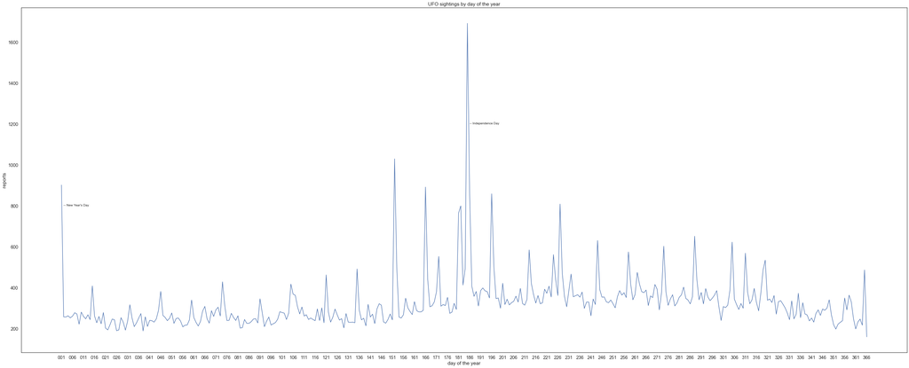

```python
plt.figure(figsize=(50,20))
plt.title('UFO sightings by day of the year')
plt.xlabel('day of the year')
plt.ylabel('reports')
plt.xticks(xticks)
plt.text(1, 800,'-- New Year\'s Day')
plt.text(185, 1200, '-- Independence Day')
plt.plot(days, reports)
```

```python
ufo_days.groupby('day of the year').count()
```

| day of the year | Link | Occurred | Reported | Posted | City | State | Country | Shape | Duration | Characteristics | Images |
| --- | --- | --- | --- | --- | --- | --- | --- | --- | --- | --- | --- |
| 001 | 903 | 903 | 903 | 903 | 900 | 903 | 903 | 877 | 866 | 657 | 903 |
| 002 | 259 | 259 | 259 | 259 | 258 | 259 | 259 | 251 | 251 | 203 | 259 |
| 003 | 258 | 258 | 258 | 258 | 258 | 258 | 258 | 248 | 246 | 200 | 258 |
| 004 | 264 | 264 | 264 | 264 | 264 | 264 | 264 | 255 | 250 | 206 | 264 |
| 005 | 254 | 254 | 254 | 254 | 253 | 254 | 254 | 244 | 244 | 184 | 254 |
| ... | ... | ... | ... | ... | ... | ... | ... | ... | ... | ... | ... |
| 362 | 234 | 234 | 234 | 234 | 234 | 234 | 234 | 225 | 226 | 176 | 234 |
| 363 | 248 | 248 | 248 | 248 | 248 | 248 | 248 | 234 | 232 | 177 | 248 |
| 364 | 218 | 218 | 218 | 218 | 218 | 218 | 218 | 208 | 206 | 164 | 218 |
| 365 | 488 | 488 | 488 | 488 | 487 | 488 | 488 | 476 | 475 | 341 | 488 |
| 366 | 161 | 161 | 161 | 161 | 161 | 161 | 161 | 157 | 155 | 118 | 161 |

366 rows × 11 columns

```python
ufo_days.groupby('day of the year').count().sort_values('Link', ascending=False)
```

| day of the year | Link | Occurred | Reported | Posted | City | State | Country | Shape | Duration | Characteristics | Images |
| --- | --- | --- | --- | --- | --- | --- | --- | --- | --- | --- | --- |
| 185 | 1693 | 1693 | 1693 | 1693 | 1693 | 1693 | 1693 | 1664 | 1663 | 1207 | 1693 |
| 152 | 1031 | 1031 | 1031 | 1031 | 1029 | 1031 | 1031 | 994 | 983 | 703 | 1031 |
| 001 | 903 | 903 | 903 | 903 | 900 | 903 | 903 | 877 | 866 | 657 | 903 |
| 166 | 893 | 893 | 893 | 893 | 893 | 893 | 893 | 871 | 864 | 620 | 893 |
| 186 | 865 | 865 | 865 | 865 | 864 | 865 | 865 | 852 | 846 | 645 | 865 |
| ... | ... | ... | ... | ... | ... | ... | ... | ... | ... | ... | ... |
| 027 | 195 | 195 | 195 | 195 | 195 | 195 | 195 | 189 | 182 | 148 | 195 |
| 030 | 194 | 194 | 194 | 194 | 194 | 194 | 194 | 188 | 186 | 151 | 194 |
| 026 | 191 | 191 | 191 | 191 | 191 | 191 | 191 | 185 | 181 | 140 | 191 |
| 038 | 190 | 190 | 190 | 190 | 189 | 190 | 190 | 183 | 178 | 145 | 190 |
| 366 | 161 | 161 | 161 | 161 | 161 | 161 | 161 | 157 | 155 | 118 | 161 |

366 rows × 11 columns

```python
ufo_summaries = ufo_og.copy()
ufo_summaries = ufo_summaries.set_index(ufo_summaries.Summary)
ufo_summaries = ufo_summaries["Summary"]
```

```python
swords = stopwords.words('english')  # basic stopword library

swords.append('UFO')
swords.append('ufo')
swords.append('nuforc')

# adding UFO and ufo to the stopwords list because they will be so often used because it is the subject matter I don't
# believe that they will be useful.
```

```python
summary_list = list(ufo_summaries)
token_list= []

for ufo_string in summary_list:
    str(ufo_string)
    token_list.append(nltk.word_tokenize(str(ufo_string)))
```

```python
word_list = [item for word_list in token_list for item in word_list]
len(word_list)

import string
word_list = [w for w in word_list if w not in string.punctuation]
word_list = [w for w in word_list if w not in swords]
word_list = [w.lower() for w in word_list]

stemmer = nltk.stem.snowball.EnglishStemmer()  # grab me a "snowball stemmer"
word_list = [stemmer.stem(w) for w in word_list]
```

```python
word_list = [w for w in word_list if not isinstance(w, int)]
```

```python
fd = nltk.probability.FreqDist(word_list)
```

```python
fd.most_common(50)
```

```
[('i', 635352),
 ('light', 298917),
 ('object', 170537),
 ('sky', 142264),
 ('it', 140267),
 ('move', 129307),
 ('look', 128170),
 ('the', 126982),
 ('saw', 108612),
 ('like', 102337),
 ('see', 89188),
 ('one', 86110),
 ('bright', 84418),
 ('time', 76038),
 ('could', 68484),
 ('appear', 65005),
 ('we', 62317),
 ('seen', 61894),
 ('shape', 58967),
 ('would', 55252),
 ('wit', 53261),
 ('craft', 51968),
 ('white', 51727),
 ('star', 51202),
 ('second', 50777),
 ('back', 49261),
 ('sight', 49201),
 ("n't", 49170),
 ('night', 49131),
 ('minut', 48817),
 ('two', 47881),
 ('direct', 46344),
 ('around', 46321),
 ('fli', 45900),
 ('red', 45763),
 ('seem', 44836),
 ('watch', 44181),
 ('disappear', 43039),
 ('note', 42997),
 ('went', 42991),
 ('first', 42971),
 ('notic', 42904),
 ('go', 40072),
 ('nuforc', 39607),
 ("''", 38037),
 ('pd', 38026),
 ('north', 37940),
 ('plane', 37868),
 ('sound', 37811),
 ('``', 36847)]
```

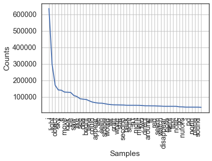

```python
fd.plot(50)
```

```python
import sklearn.feature_extraction.text as skft

# Run LDA on the tales dataset.
n_features = 1000
n_topics = 5
n_top_words = 20

# "we're going to use the same code as above with a few changes. We want to limit the frequency...
# so let's keep around only words that appear in more than two document but in less than 70%
# let's also restrict ourselves to 1000 words and remove stopwords
tf_vectorizer = skft.CountVectorizer(max_df=0.7, min_df=2, max_features=n_features, stop_words='english')
tf_ufo = tf_vectorizer.fit_transform(word_list)
```

```python
lda = skd.LatentDirichletAllocation(n_components = 10, max_iter=5,
                                    learning_method='online',
                                    learning_offset=50.,
                                    random_state=0)
```

```python
lda.fit(tf_ufo);
```

```python
# a helper function to print the topics and the top words in each
def print_top_words(model, feature_names, n_top_words):
    for topic_idx, topic in enumerate(model.components_):
        print("Topic #%d:" % topic_idx)
        print(" ".join([feature_names[i]
                        for i in topic.argsort()[:-n_top_words - 1:-1]]))
    print()

print("Topics in LDA model:")
tf_feature_names = tf_vectorizer.get_feature_names()
print_top_words(lda, tf_feature_names, n_top_words)
```

```
Topics in LDA model:
Topic #0:
wit white east flash area drive friend way home near later degre triangl think strang spot happen believ visibl realli
Topic #1:
sky bright direct disappear cloud come slowli mile anoth straight took road pass air inform pictur stay indic ask sphere
Topic #2:
saw sound pd high point came start feet make glow ball nois quick eye moon tri wife walk tell provid
Topic #3:
sight hous larg left view date distanc slow sever sudden continu ground flew say video hour circl satellit lake silent
Topic #4:
shape second watch orang hover aircraft 10 observ outsid year window 20 mayb told littl end sit sinc old similar
Topic #5:
like appear red nuforc turn speed line car green anyth format remain jet day 15 contact long mani slight pattern
Topic #6:
look west plane away head 30 blue gone event locat began complet shoot binocular insid circular kept stand apart rate
Topic #7:
object seen south report travel approxim tree fast size close low dark heard work noth elect trail pm mountain exact
Topic #8:
light craft right got clear stop said chang small horizon blink total orb altitud husband kind extrem fall vanish sort
Topic #9:
time star night minut fli went north note notic thought color know thing someth follow airplan helicopt live round far
```

### The clustering is not super clear, and more data would be needed to perform better clustering

### Can we build a classifier based on summaries to guess shape?

```python
ufo_train, ufo_test = skcv.train_test_split(ufo_og, test_size=0.3, random_state=0)
# let's "vectorize" the content
vectorizer = skft.CountVectorizer(max_df=0.7)
X_train = vectorizer.fit_transform(ufo_train['Summary'].values.astype('U'))
```

```python
pipeline = skpipe.Pipeline(
    [('vect', skft.CountVectorizer(max_df=0.7)),
     ('tfidf', skft.TfidfTransformer()),
     ('clf', sknb.MultinomialNB())])

pipeline.fit(ufo_train['Summary'].values.astype('U'), ufo_train['Shape'].values.astype('U'));
```

```python
import sklearn.metrics as skmetrics

test_predicted = pipeline.predict(ufo_test['Summary'].values.astype('U'))
print ('Accuracy:', skmetrics.accuracy_score(ufo_test['Shape'].str.lower().astype(str), test_predicted))
print (skmetrics.classification_report(ufo_test['Shape'].str.lower().astype(str), test_predicted))
```

```
Accuracy: 0.01686262796317919
              precision    recall  f1-score   support

      Circle       0.00      0.00      0.00         0
        Disk       0.00      0.00      0.00         0
    Fireball       0.00      0.00      0.00         0
       Light       0.00      0.00      0.00         0
       Other       0.00      0.00      0.00         0
      Sphere       0.00      0.00      0.00         0
    Triangle       0.00      0.00      0.00         0
    changing       0.00      0.00      0.00       941
     chevron       0.00      0.00      0.00       436
       cigar       0.00      0.00      0.00       874
      circle       0.00      0.00      0.00      3935
        cone       0.00      0.00      0.00       140
       cross       0.00      0.00      0.00       119
    cylinder       0.00      0.00      0.00       573
       delta       0.00      0.00      0.00         2
     diamond       0.00      0.00      0.00       514
        disk       0.00      0.00      0.00      2120
        dome       0.00      0.00      0.00         1
         egg       0.00      0.00      0.00       293
    fireball       0.00      0.00      0.00      2576
       flare       0.00      0.00      0.00         1
       flash       0.00      0.00      0.00       610
   formation       0.00      0.00      0.00      1246
     hexagon       0.00      0.00      0.00         1
       light       0.00      0.00      0.00      7507
         nan       0.99      0.37      0.54      1657
       other       0.00      0.00      0.00      2492
        oval       0.00      0.00      0.00      1567
     pyramid       0.00      0.00      0.00         1
   rectangle       0.00      0.00      0.00       599
      sphere       0.00      0.00      0.00      2414
        star       0.00      0.00      0.00        10
    teardrop       0.00      0.00      0.00       305
    triangle       0.00      0.00      0.00      3339
     unknown       0.00      0.00      0.00      2554

    accuracy                           0.02     36827
   macro avg       0.03      0.01      0.02     36827
weighted avg       0.04      0.02      0.02     36827
```

### Nope, no good. Too many shapes with not enough data, I think. Maybe we can if we only look at data with the most common shapes.

```python
ufo_common = ufo_og.copy()
ufo_common = ufo_common[(ufo_common['Shape'] == 'light') | (ufo_common['Shape'] == 'disk')
                       | (ufo_common['Shape'] == 'triangle')]
ufo_common.groupby('Shape').count()
```

| Shape | Link | Occurred | Reported | Posted | City | State | Country | Duration | Characteristics | Summary | Images |
| --- | --- | --- | --- | --- | --- | --- | --- | --- | --- | --- | --- |
| light | 58 | 58 | 58 | 58 | 58 | 58 | 58 | 56 | 3 | 58 | 58 |
| triangle | 18 | 18 | 18 | 18 | 18 | 18 | 18 | 17 | 0 | 18 | 18 |

```python
ufo_ctrain, ufo_ctest = skcv.train_test_split(ufo_common, test_size=0.3, random_state=0)

pipeline = skpipe.Pipeline(
    [('vect', skft.CountVectorizer(max_df=0.7)),
     ('tfidf', skft.TfidfTransformer()),
     ('clf', sknb.MultinomialNB())])

pipeline.fit(ufo_ctrain["Summary"], ufo_ctrain['Shape']);

import sklearn.metrics as skmetrics

test_predicted = pipeline.predict(ufo_ctest["Summary"])
print ('Accuracy:', skmetrics.accuracy_score(ufo_ctest['Shape'], test_predicted))
print (skmetrics.classification_report(ufo_ctest['Shape'], test_predicted))
```

```
Accuracy: 0.8260869565217391
              precision    recall  f1-score   support

       light       0.83      1.00      0.90        19
    triangle       0.00      0.00      0.00         4

    accuracy                           0.83        23
   macro avg       0.41      0.50      0.45        23
weighted avg       0.68      0.83      0.75        23
```

### Better but still not particularly accurate. Summaries don't seem like a good enough indicator of shape, especially because there are so many shape options but only a few have a lot of reports

```python
import re
lexicon = {}
value_map = {'positive': 1, 'neutral': 0, 'negative': -1}
with open('subjclueslen1-HLTEMNLP05.tff.txt') as reader:
    for line in reader:
        m = re.match(".*\sword1=(\w+)\s.*priorpolarity=(positive|neutral|negative)", line)
        if m:
            m = m.groups()
            assert len(m) == 2
            lexicon[m[0]] = value_map[m[1]]
```

```python
def get_sentiment(lexicon, s):
    if not isinstance(s, str):
        print('s')
    tokens = s.lower().split()
    tokens = map(stemmer.stem, tokens)
    scores = [lexicon[t] for t in tokens if t in lexicon]
    return 'pos' if sum(scores) > 0 else 'neut' if sum(scores) == 0 else 'neg'
```

```python
def get_sentiment_series(lexicon, s):
    lst = list(s)
    for x in lst:

        tokens = str(x).lower().split()
        tokens = map(stemmer.stem, tokens)
        scores = [lexicon[t] for t in tokens if t in lexicon]
    return 'pos' if sum(scores) > 0 else 'neut' if sum(scores) == 0 else 'neg'
```

```python
predicted_labels = [get_sentiment(lexicon, x) for x in ufo_og["Summary"].astype(str)]
```

```python
pos_ufo = predicted_labels.count('pos')/len(predicted_labels)
neg_ufo = predicted_labels.count('neg')/len(predicted_labels)
neut_ufo = predicted_labels.count('neut')/len(predicted_labels)

print('Percent of positive reviews: ', pos_ufo*100)
print('Percent of neutral reviews: ', neut_ufo*100)
print('Percent of negative reviews: ', neg_ufo*100)

ufo_sent = ufo_og.copy()
ufo_sent['sentiment'] = predicted_labels

ufo_sent[['Summary','sentiment']].sample(10)
```

```
Percent of positive reviews:  70.17205141991299
Percent of neutral reviews:  10.615540023135702
Percent of negative reviews:  19.212408556951303
```

| Occurred | Summary | sentiment |
| --- | --- | --- |
| 2022-02-28 03:53:00 | One craft had red color the other was a white ... | pos |
| 2017-11-06 20:00:00 | Circular orange formation over LIncoln/LIberty... | pos |
| 2018-02-06 19:00:00 | Four soft glowing white orbs to the north. Tw... | pos |
| 2022-03-05 21:30:00 | 3 orbs in a straight line perfectly spaced apa... | pos |
| 2009-02-16 19:30:00 | Very blue light traveling FAST from north to s... | pos |
| 2019-09-17 20:30:00 | I have pictures\n\nLooked like 3 lights though... | pos |
| 1980-12-27 11:00:00 | frozen in time \n\nIt was during x-mas vacati... | neg |
| 2010-03-30 09:00:00 | bright light spotted in port charlotte FL\n\nm... | pos |
| 2003-12-30 18:00:00 | Happened in rochester ny lasted 10 minutes 3 l... | pos |
| NaT | SUMMARY: 2 adult women about 1 mile apart saw... | pos |

```python
# takes a looong time to run on so many entries
# summm = ufo_sent.loc[:,"Summary"]
# x = get_sentiment_series(lexicon,summm)
```

```python
state_pops = {
    "AL" : "4949697", "AK" : "720763", "AZ" : "7640796", "AR" : "3042017", "CA" : "39664128", "CO" : "5961083", "CT" : "3546588", "DE" : "998619", "FL" : "22177997", "GA" : "10936299", "HI" : "1401709", "ID" : "1896652", "IL" : "12518071", "IN" : "6842385", "IA" : "3174426", "KS" : "2919179", "KY" : "4487233", "LA" : "4616106", "ME" : "1359677", "MD" : "6075314", "MA" : "6922107", "MI" : "9995212", "MN" : "5739781", "MS" : "2961536", "MO" : "6184843", "MT" : "1093117", "NE" : "1960790", "NV" : "3238601", "NH" : "1378449", "NJ" : "8870685", "NM" : "2109093", "NY" : "19223191", "NC" : "10807491", "ND" : "774008", "OH" : "11727377", "OK" : "4007179", "OR" : "4325290", "PA" : "12805190", "RI" : "1062583", "SC" : "5342388", "SD" : "902542", "TN" : "7001803", "TX" : "30097526", "UT" : "3363182", "VT" : "622882", "VA" : "8638218", "WA" : "7887965", "WV" : "1755715", "WI" : "5867518", "WY" : "582233"
}

states_ufo = ufo_states[ufo_states['State'] != 'DC'].groupby('State').count()
states_ufo['State Population'] = state_pops.values()
# states_ufo['Time'] = states_ufo['Time'].astype(float)
states_ufo
```

| State | Link | Occurred | Reported | Posted | City | Country | Shape | Duration | Characteristics | Summary | Images | State Population |
| --- | --- | --- | --- | --- | --- | --- | --- | --- | --- | --- | --- | --- |
| AK | 608 | 595 | 608 | 608 | 607 | 608 | 587 | 592 | 450 | 608 | 608 | 4949697 |
| AL | 1267 | 1252 | 1267 | 1267 | 1265 | 1267 | 1223 | 1208 | 928 | 1267 | 1267 | 720763 |
| AR | 1182 | 1162 | 1182 | 1182 | 1181 | 1182 | 1069 | 1047 | 813 | 1182 | 1182 | 7640796 |
| AZ | 4629 | 4547 | 4629 | 4629 | 4621 | 4629 | 4447 | 4414 | 3367 | 4627 | 4629 | 3042017 |
| CA | 15122 | 14802 | 15122 | 15122 | 15114 | 15122 | 14607 | 14607 | 10981 | 15120 | 15122 | 39664128 |
| CO | 2995 | 2957 | 2995 | 2995 | 2992 | 2995 | 2853 | 2817 | 2150 | 2994 | 2995 | 5961083 |
| CT | 1879 | 1856 | 1879 | 1879 | 1876 | 1879 | 1733 | 1711 | 1333 | 1878 | 1879 | 3546588 |
| DE | 379 | 378 | 379 | 379 | 379 | 379 | 374 | 362 | 305 | 378 | 379 | 998619 |
| FL | 7589 | 7496 | 7589 | 7589 | 7584 | 7589 | 7299 | 7242 | 5544 | 7584 | 7589 | 22177997 |
| GA | 2513 | 2490 | 2513 | 2513 | 2511 | 2513 | 2413 | 2380 | 1921 | 2512 | 2513 | 10936299 |
| HI | 640 | 630 | 640 | 640 | 640 | 640 | 623 | 624 | 452 | 640 | 640 | 1401709 |
| IA | 1140 | 1125 | 1140 | 1140 | 1137 | 1140 | 1098 | 1093 | 824 | 1140 | 1140 | 1896652 |
| ID | 1266 | 1241 | 1266 | 1266 | 1264 | 1266 | 1168 | 1169 | 864 | 1266 | 1266 | 12518071 |
| IL | 4034 | 3977 | 4034 | 4034 | 4031 | 4034 | 3865 | 3794 | 2937 | 4033 | 4034 | 6842385 |
| IN | 2534 | 2507 | 2534 | 2534 | 2528 | 2534 | 2206 | 2157 | 1709 | 2534 | 2534 | 3174426 |
| KS | 1104 | 1085 | 1104 | 1104 | 1101 | 1104 | 1050 | 1054 | 814 | 1104 | 1104 | 2919179 |
| KY | 1582 | 1565 | 1582 | 1582 | 1579 | 1582 | 1534 | 1505 | 1211 | 1582 | 1582 | 4487233 |
| LA | 1042 | 1030 | 1042 | 1042 | 1041 | 1042 | 1015 | 1002 | 757 | 1042 | 1042 | 4616106 |
| MA | 2484 | 2455 | 2484 | 2484 | 2480 | 2484 | 2397 | 2379 | 1863 | 2484 | 2484 | 1359677 |
| MD | 1678 | 1656 | 1678 | 1678 | 1677 | 1678 | 1624 | 1615 | 1233 | 1678 | 1678 | 6075314 |
| ME | 1112 | 1091 | 1112 | 1112 | 1111 | 1112 | 1069 | 1072 | 815 | 1112 | 1112 | 6922107 |
| MI | 3400 | 3325 | 3400 | 3400 | 3399 | 3400 | 3251 | 3254 | 2490 | 3399 | 3400 | 9995212 |
| MN | 1973 | 1951 | 1973 | 1973 | 1970 | 1973 | 1906 | 1893 | 1424 | 1971 | 1973 | 5739781 |
| MO | 2632 | 2575 | 2632 | 2632 | 2627 | 2632 | 2471 | 2452 | 1855 | 2631 | 2632 | 2961536 |
| MS | 734 | 724 | 734 | 734 | 732 | 734 | 719 | 699 | 584 | 734 | 734 | 6184843 |
| MT | 941 | 917 | 941 | 941 | 938 | 941 | 877 | 881 | 652 | 941 | 941 | 1093117 |
| NC | 3380 | 3352 | 3380 | 3380 | 3375 | 3380 | 3316 | 3270 | 2550 | 3380 | 3380 | 1960790 |
| ND | 263 | 252 | 263 | 263 | 262 | 263 | 232 | 236 | 176 | 263 | 263 | 3238601 |
| NE | 651 | 646 | 651 | 651 | 649 | 651 | 633 | 634 | 472 | 651 | 651 | 1378449 |
| NH | 1102 | 1100 | 1102 | 1102 | 1100 | 1102 | 1027 | 1022 | 785 | 1102 | 1102 | 8870685 |
| NJ | 2689 | 2662 | 2689 | 2689 | 2685 | 2689 | 2570 | 2548 | 2003 | 2687 | 2689 | 2109093 |
| NM | 1538 | 1521 | 1538 | 1538 | 1531 | 1538 | 1473 | 1466 | 1096 | 1537 | 1538 | 19223191 |
| NV | 1578 | 1539 | 1578 | 1578 | 1568 | 1578 | 1511 | 1522 | 1104 | 1578 | 1578 | 10807491 |
| NY | 5455 | 5390 | 5455 | 5455 | 5448 | 5455 | 5230 | 5211 | 4014 | 5455 | 5455 | 774008 |
| OH | 4154 | 4111 | 4154 | 4154 | 4145 | 4154 | 3932 | 3859 | 3040 | 4154 | 4154 | 11727377 |
| OK | 1367 | 1352 | 1367 | 1367 | 1365 | 1367 | 1335 | 1320 | 1027 | 1367 | 1367 | 4007179 |
| OR | 3325 | 3218 | 3325 | 3325 | 3324 | 3325 | 3164 | 3215 | 2301 | 3321 | 3325 | 4325290 |
| PA | 4626 | 4561 | 4626 | 4626 | 4618 | 4626 | 4451 | 4414 | 3357 | 4626 | 4626 | 12805190 |
| RI | 567 | 556 | 567 | 567 | 566 | 567 | 554 | 552 | 412 | 567 | 567 | 1062583 |
| SC | 2100 | 2089 | 2100 | 2100 | 2097 | 2100 | 2039 | 2014 | 1590 | 2098 | 2100 | 5342388 |
| SD | 364 | 357 | 364 | 364 | 362 | 364 | 346 | 350 | 268 | 364 | 364 | 902542 |
| TN | 2129 | 2097 | 2129 | 2129 | 2126 | 2129 | 2030 | 2023 | 1565 | 2129 | 2129 | 7001803 |
| TX | 5666 | 5593 | 5666 | 5666 | 5655 | 5666 | 5509 | 5424 | 4175 | 5664 | 5666 | 30097526 |
| UT | 1408 | 1387 | 1408 | 1408 | 1404 | 1408 | 1361 | 1360 | 991 | 1407 | 1408 | 3363182 |
| VA | 2505 | 2466 | 2505 | 2505 | 2495 | 2505 | 2385 | 2371 | 1840 | 2505 | 2505 | 622882 |
| VT | 563 | 556 | 563 | 563 | 561 | 563 | 550 | 544 | 426 | 562 | 563 | 8638218 |
| WA | 6743 | 6380 | 6743 | 6743 | 6739 | 6743 | 6156 | 6354 | 4449 | 6741 | 6743 | 7887965 |
| WI | 2282 | 2258 | 2282 | 2282 | 2280 | 2282 | 2228 | 2220 | 1698 | 2282 | 2282 | 1755715 |
| WV | 844 | 831 | 844 | 844 | 841 | 844 | 817 | 809 | 646 | 844 | 844 | 5867518 |
| WY | 377 | 371 | 377 | 377 | 376 | 377 | 364 | 364 | 265 | 377 | 377 | 582233 |

```python
states_ufo['ratio of count and state population'] = states_ufo['Link'].astype(int) / states_ufo['State Population'].astype(int) * 100
```

```python
states_ufo.sort_values('ratio of count and state population')
np.sort(states_ufo['State Population'])
```

```
array(['1062583', '10807491', '1093117', '10936299', '11727377',
       '12518071', '12805190', '1359677', '1378449', '1401709', '1755715',
       '1896652', '19223191', '1960790', '2109093', '22177997', '2919179',
       '2961536', '30097526', '3042017', '3174426', '3238601', '3363182',
       '3546588', '39664128', '4007179', '4325290', '4487233', '4616106',
       '4949697', '5342388', '5739781', '582233', '5867518', '5961083',
       '6075314', '6184843', '622882', '6842385', '6922107', '7001803',
       '720763', '7640796', '774008', '7887965', '8638218', '8870685',
       '902542', '998619', '9995212'], dtype=object)
```

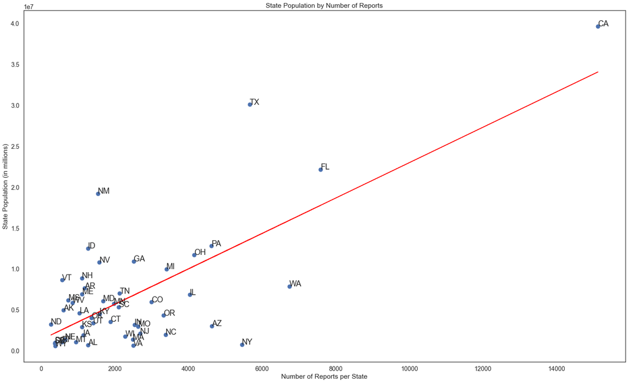

```python
states_ufo.sort_values('ratio of count and state population', ascending=False)
plt.figure(figsize=(25,15))
plt.xlabel('Number of Reports per State')
plt.ylabel('State Population (in millions)')
plt.title('State Population by Number of Reports')

states_ufo = states_ufo.rename(columns={'Link':'number of reports'})

x = states_ufo['number of reports'].astype(int)
y = states_ufo['State Population'].astype(int)
xy = []
yz = []
for v in x:
    xy.append(str(v))
for v in y:
    yz.append(str(v))

plt.scatter(x=x,y=y,s=80)

plt.rcParams.update({'font.size':18})

for i, txt in enumerate(states_ufo.index):
    plt.annotate(txt, (x[i],y[i]))

fit = np.polyfit(x, y, deg=1)
plt.plot(x, fit[0] * x + fit[1], color='red')
```

[output not shown]

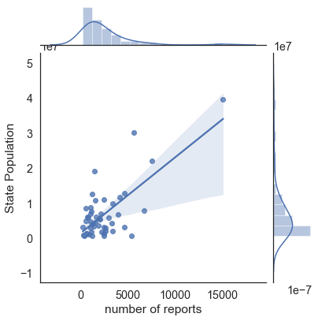

```python
from scipy import stats

gp = sns.JointGrid(x=x,y=y)
gp = gp.plot(sns.regplot, sns.distplot)
# gp = gp.annotate(stats.pearsonr)

states_ufo.corr('pearson').drop('ratio of count and state population',axis=1).drop('ratio of count and state population', axis=0)
```